# Problem Set 08: Inference for Regression (30 pts)

Authorized Resources: Anyone and anything.

# Introduction

For this problem set you will apply statistical inference to a linear model and explore methods to check the required conditions. To start we will build a model using data from the `palmerpenguins` package. The `penguins` data contains size measurements for three penguin species observed on three islands in the Palmer Archipelago, Antarctica.

First we will start with our typical exploratory data analysis and then build our linear model. From there we will use our new skills to make inferences about our regression model and check the necessary conditions.

## Markdown File

Just like the first problem set, you will create an rmarkdown file; you can refer to the first problem set for instruction. Name your file with the following format: **PS08_lastname_firstname_section**

Fill in your answers to the exercises below with a corresponding exercise header in your rmarkdown file. Be sure to include text *and* code where necessary.

## Deliverable

- You will turn in your completed problem set as a **knitted pdf file** to Gradescope.
- Include a documentation statement.
- Each exercise is worth 3 points.
- Be sure to **make a header to label each Exercise**, this means using # followed by the word Exercise and the exercise number.
- Please type your code to answer the questions in a code chunk (gray part), under the exercise headers and type (**BRIEF**) answers to any interpretation questions in the white part under the headers.

## Setup

First load the necessary packages:

```r
library(tidyverse)
library(moderndive)
library(infer)
library(palmerpenguins)
```

## The data

```r
pen <-penguins  %>%
  filter(!is.na(flipper_length_mm))
```

Take a moment to look at the data in the viewer. The dataset contains 8 variables. You can read more about the variables by typing ?penguins

For our lab we will focus on four variables, the explanatory variables include:

- `flipper_length_mm` - an integer denoting flipper length (millimeters)
- `bill_length_mm` - a number denoting bill length (millimeters)
- `species`- denotes penguin species (Adélie, Chinstrap and Gentoo)

The outcome variable `body_mass_g` is an integer denoting body mass (grams).

## Visualization

We will start by investigating the relationship between ‘flipper_length_mm’ and ‘body_mass_g’.

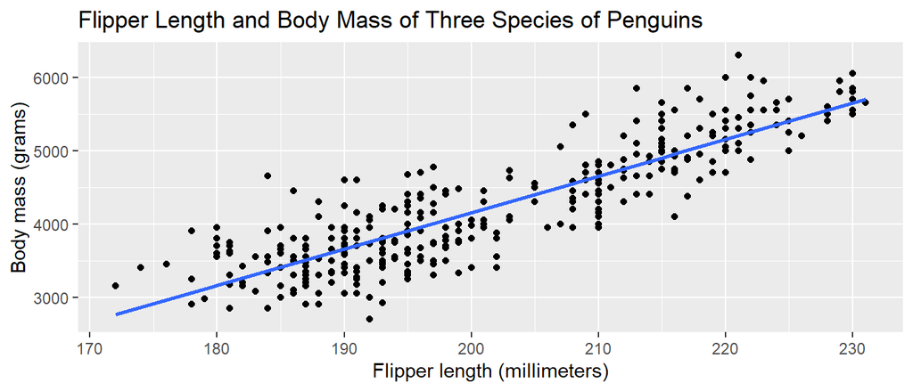

```r
ggplot(data = pen, aes(y = body_mass_g, x = flipper_length_mm)) +
  geom_point() +
  geom_smooth(method = "lm", se = FALSE) +
  labs(x = "Flipper length (millimeters)",
       y = "Body mass (grams)",
       title = "Flipper Length and Body Mass of Three Species of Penguins")
```

1. Does the relationship appear to be positive or negative? Does it look to be reasonably linear?

## Create a linear regression model

```r
pen_model <- lm(body_mass_g ~ flipper_length_mm, data = pen)
get_regression_table(pen_model)
```

```
## # A tibble: 2 x 7
##   term              estimate std_error statistic p_value lower_ci upper_ci
##   <chr>                <dbl>     <dbl>     <dbl>   <dbl>    <dbl>    <dbl>
## 1 intercept          -5781.     306.       -18.9       0  -6382.   -5179.
## 2 flipper_length_mm     49.7      1.52      32.7       0     46.7     52.7
```

1. Using our shorthand interpretation for confidence intervals and the regression table, write a sentence interpreting the 95% confidence interval for $\beta_1$.
2. Recall that the test statistic and $p$-value correspond to the hypothesis test:
   $$\begin{aligned} H_0:&\beta_{1} =
   0 \\\ \mbox{vs }H_A:& \beta_{1} \neq 0 \end{aligned}$$
   Write up the results & conclusions for this hypothesis test.

You may remember that this hypothesis test is only valid if certain “conditions for inference for regression” are met. Let’s take a closer look those conditions.

- Linearity of relationship between variables
- Independence of the residuals
- Normality of the residuals
- Equality of variance of the residuals

## Linearity of relationship between variables

1. Did you say that the relationship between `flipper_length_mm` and `body_mass_g` appears to be linear?

## Independence of the residuals

The observations in our data must be independent of one another. In this data, we can not be sure this is case. For example, some of the penguins included may be related (siblings, parents). We are not given enough information to verify this condition has been met.

## Normality of the residuals

The third condition is that the residuals should follow a normal distribution centered 0. To check for normality, create a histogram.

The code to get the residuals is given.

```r
regression_points <- get_regression_points(pen_model)
```

1. Plot a histogram and report whether normality is a reasonable assumption.

```r
#Add code for the histogram.
```

## Equality of variance of the residuals

The final condition says that the residuals should exhibit equal variance across all of the values of the explanatory variable.

To check this condition we can create a scatterplot that has our explanatory variable, `flipper_length_mm`, on the x-axis and our residuals on the y-axis.

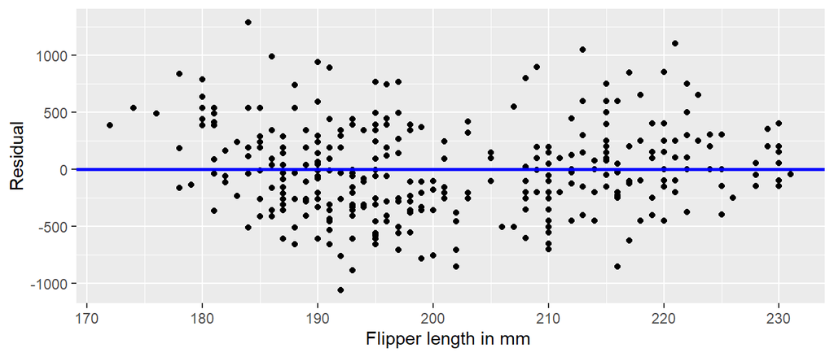

```r
ggplot(regression_points, aes(x = flipper_length_mm, y = residual)) +
  geom_point() +
  labs(x = "Flipper length in mm ", y = "Residual") +
  geom_hline(yintercept = 0, col = "blue", size = 1)
```

1. Does this model meet the equality of variance of residuals condition?

## Find a 95% confidence interval

Now let’s circle back and take a second look at the confidence intervals. Using this bootstrap distribution, we’ll construct the 95% confidence interval using the percentile method and (if appropriate) the standard error method as well. We can compare our results to the results from R (which uses mathematical formula to construct confidence intervals.)

### Step 1: Calculate the bootstrap statistic and Visualize the bootstrap distribution

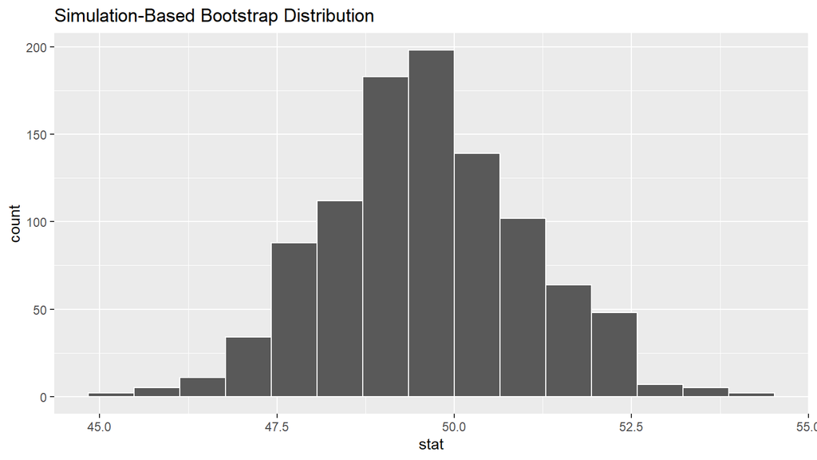

```r
set.seed(126)
bootstrap_distn_slope <- pen %>%
  specify(formula = body_mass_g ~ flipper_length_mm) %>%
  generate(reps = 1000, type = "bootstrap") %>%
  calculate(stat = "slope")
visualize(bootstrap_distn_slope)
```

### Step 2: Calculate CI from the a bootstrap resample two ways

Find a 95% CI using the percentile method.

```r
#finish the code here:
#bootstrap_distn_slope %>%
```

Find a 95% CI using the standard error method.

```r
#finish the code here:
#observed_slope <- pen %>%
#bootstrap_distn_slope %>%
```

1. Report the 95% confidence intervals that you found using the two bootstrap methods.

## Another Model

For the next part you will check the conditions for regression inference for a new model. This model will have `bill_length_mm` and `species` as explanatory variables, and we’ll use the parallel slopes model. Let’s fit the parallel slopes model.

```r
# Fit regression model:
pen_parallel <- lm(body_mass_g ~ bill_length_mm + species, data = pen)

# Get regression table:
get_regression_table(pen_parallel)
```

```
## # A tibble: 4 x 7
##   term               estimate std_error statistic p_value lower_ci upper_ci
##   <chr>                 <dbl>     <dbl>     <dbl>   <dbl>    <dbl>    <dbl>
## 1 intercept             154.     269.       0.572   0.568   -375.      683.
## 2 bill_length_mm         91.4      6.89    13.3     0         77.9     105.
## 3 species: Chinstrap   -886.      88.2    -10.0     0      -1059.     -712.
## 4 species: Gentoo       579.      75.4      7.68    0        430.      727.
```

```r
# Get regression points:
regression_points_par <- get_regression_points(pen_parallel)
```

Let us once again inspect the conditions necessary for inference with regression.

- Linearity of relationship between variables
- Independence of the residuals
- Normality of the residuals
- Equality of variance of the residuals
1. Check for Linearity of relationship between variables

```r
# Insert code here
```

**Check for Independence of the residuals**

This is the same as the first model that we looked it. The observations in our data must be independent of one another. In this data, we can not be sure this is case, for example, some of the penguins included may be related (siblings, parents). We are not given enough information to verify this condition has been met.

1. Check Normality of the residuals (and they should be centered at 0.)

```r
#Add code for the histogram:
```

1. Check for equality of variance of the residuals

```r
#Add code to check this condition:
```

## Documenting software

- File creation date: 2022-07-15
- R version 4.1.3 (2022-03-10)
- `tidyverse` package version: 1.3.1
- `infer` package version: 1.0.2
- `moderndive` package version: 0.5.4
- `palmerpenguins` package version: 0.1.0